# Applied Likelihood & Simulation for the Normal Model

## Simulation from the Model to Assess Hypothesis and Counterfactuals

- Simulating from our model allows us to examine the impact of different values of our IV’s, $\mathbf{X}$, on the dependent variable $y$.
- It also allows us to assess how $y$ behaves under different counterfactual scenarios (e.g., what’s the probability that a black, male, with a Ph.D. votes?)
- We construct these counterfactuals such that we can explore any substantive question we like from the data.

Let’s examine the P(y|x_1) across its range.

- Here we simply create a variable that takes on all values in the range of $x_1$ by .001.

```r
x_1_range <- seq(min(x_1), max(x_1), by = .001)
```

- Set up a data frame for hypothesis regarding $x_1$ - holding all else equal—mean_model is the model with all variables held at the mean.
- Create a matrix of repreated means for each variable that is the length of the range of x_1 by .001.

```r
mean_model <- c(mean(x_1), mean(x_2))
cf_1 <- matrix(mean_model, nrow = length(x_1_range), ncol = 2, byrow = TRUE)
cf_1 <- data.frame(cf_1)
colnames(cf_1) <- c("x_1", "x_2")

# Take a look
head(cf_1)
```

|  | x_1 | x_2 |
| --- | --- | --- |
| 1 | 21.9997 | 7.008283 |
| 2 | 21.9997 | 7.008283 |
| 3 | 21.9997 | 7.008283 |
| 4 | 21.9997 | 7.008283 |
| 5 | 21.9997 | 7.008283 |
| 6 | 21.9997 | 7.008283 |

- Predictions from this counterfactual would give us the expectation for $y$ with all variables held at their means.
- Now, lets replace the $x_1$ column with our counterfactual about $x_1$ and confirm that we were successful.

```r
cf_1[,1] <- x_1_range
head(cf_1)
```

|  | x_1 | x_2 |
| --- | --- | --- |
| 1 | 15.52166 | 7.008283 |
| 2 | 15.52266 | 7.008283 |
| 3 | 15.52366 | 7.008283 |
| 4 | 15.52466 | 7.008283 |
| 5 | 15.52566 | 7.008283 |
| 6 | 15.52666 | 7.008283 |

- Note that $x_1$ now increases by .001 in each row of our counterfactual data.

### Making Counterfactual Predictions for $y$

- We can use our estimated model to generate predictions about $y$ across the range of $x_1$.
- We also generate 95 percent confidence intervals for our predictions. Where “fit” is predictions for $y$, “lwr” is the lower CI, and “upr” is the upper CI.

```r
simols <- predict(ols, newdata = cf_1,
                  interval = "prediction", level = 0.95)
simols <- data.frame(simols)
head(simols)
```

|  | fit | lwr | upr |
| --- | --- | --- | --- |
| 1 | 130.9555 | 108.3599 | 153.5511 |
| 2 | 130.9601 | 108.3646 | 153.5557 |
| 3 | 130.9648 | 108.3693 | 153.5603 |
| 4 | 130.9694 | 108.3739 | 153.5649 |
| 5 | 130.9741 | 108.3786 | 153.5695 |
| 6 | 130.9787 | 108.3833 | 153.5742 |

### Assess the Counterfactual for $x_1$ Visually

- Grab a nice color from `RColorBrewer`
- Graph our predications with `ggplot2`

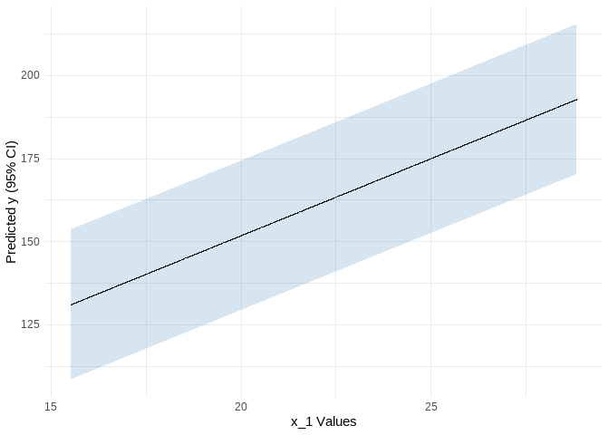

```r
fill <- brewer.pal(3, "Set1")[2] # grab a nice color

ggplot(data = simols, aes(x = cf_1$x_1)) +
  xlab("x_1 Values") +
  ylab("Predicted y (95% CI)") +
  geom_line(aes(y = fit)) +
  geom_ribbon(aes(ymin = lwr, ymax = upr),
              fill = fill, alpha = 0.2) +
  theme_minimal()
```

- Note that we could easily perform the same analysis for $x_2$. We just need to define another counterfactual data set.
  - This time we would allow $x_2$ to vary while prescribing the values of the other variables.
  - We used means for the other variables, but we could use any value that had substantive meaning given our variables (e.g., $x_3 = \text{"female"}$ or $x_4 =$ 40–60 year olds).
- Does this look right? Why would the confidence intervals display as uniform across the range of $y$?
- The predictions from our model do not take account of the *uncertainty* in our estimated $\beta$s from OLS. Remember, they are averages…they come from a distribution with variance.

## Simulation for Substantive Inference (a ‘Bayesian-esque’ Approach)

- In looking at the graphs, are we taking the distribution of the betas and uncertainty around them seriously?
- Should the confidence intervals really be constant across the range of our variables?
- Remember, our estimates for the betas represent averages or point estimates…in other words, there is a distribution associated with these. Unless our predictions about $y$ incorporate this uncertainty, our statements about $y$ aren’t entirely accurate.

### Simulating from the distribution of the betas

- To simulate, we need some information from our fitted model. Yes! OLS is particularly powerful and useful for starting a simulation for many types of models.
- What do we need from the model?
- The systematic and stochastic components of course—$\beta$s, uncertainty around the $\beta$s, and $\sigma^2$ - the variance.

```r
pe <- ols$coefficients # the betas
vc <- vcov(ols) # var-cov matrix, remember from Joe's class
se <- sqrt(diag(vc)) # standard errors
s2 <- summary(ols)$sigma**2 # the variance or sigma^2
```

- Simulate from the distribution of our betas.
- We can use the multivariate normal distribution, thanks to the Central Limit Theorem.

```r
sim_n <- 10000 # 10k simulations
simbs <- mvrnorm(sim_n, pe, vc)
simbs <- data.frame(simbs)
colnames(simbs)[1] <- "intercept" # a nicer name
head(simbs) # take a look
```

|  | intercept | x_1 | x_2 |
| --- | --- | --- | --- |
| 1 | 14.06019 | 4.494938 | 6.897720 |
| 2 | 11.22464 | 4.625690 | 6.833098 |
| 3 | 12.95272 | 4.598620 | 6.720639 |
| 4 | 7.07816 | 4.806637 | 6.848045 |
| 5 | 12.88514 | 4.512921 | 7.074548 |
| 6 | 11.21085 | 4.658453 | 6.801821 |

- We now have a data set of 10k simulations of the values of our $\beta$s based on a distribution defined by our estimates and their variances.
- We can look at these and see the distribution.

```r
ggplot(simbs, aes(x=x_1)) +
  geom_density(
    fill="#69b3a2",
    color="#e9ecef",
    alpha=0.6) +
  xlab(expression(beta[1])) +
  ylab("Density") +
  theme_tufte()
```

[figure not shown]

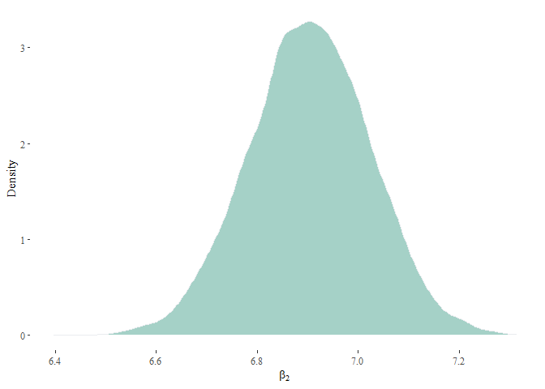

```r
ggplot(simbs, aes(x=x_2)) +
  geom_density(
    fill="#69b3a2",
    color="#e9ecef",
    alpha=0.6) +
  xlab(expression(beta[2])) +
  ylab("Density") +
  theme_tufte()
```

- So, we can now see that OLS’s $\beta$ is really one among many $\beta$s…if assumptions hold, its the most *likely* $\beta$, but if not…
- So, this is all well and good. But, how to we propagate this uncertainty into our predictions about $y$?
- To do this we will construct a matrix of means and make use of the distributional information contained in our simulated $\beta$s.

### Use Information from the OLS Model to Simulate $\beta$s

- Use these to simulate the systematic and stochastic components of $y$.

```r
sim_betas <- mvrnorm(sim_n, pe, vc) # simulate betas
mu <- sim_betas%*%t(cf_data) # systematic component mu; transpose for comformability
s2 <- summary(ols)$sigma**2 # stochastic component sigma^2

cf_y <- mu + sqrt(s2) # create the simulated $y$ values
```

- Now, we have a 10k simulations of $y$ *at each value of $x_1$* that incorporate the uncertainty, or the distribution, of our OLS $\beta$s.
- Next, we will calculate point estimates of predictions for $y$ along with confidence intervals, which logistically means grabbing the average for each set of 10k simulated values of $y$.
- First, we need to create a set of objects or “containers” to put this stuff in…

```r
ev <- NULL
lci <- NULL
uci <- NULL
```

- Calculate the quantities of interest.
  - ev: expected value of the simulated y’s is simply their mean in each column of cf_y.
  - lci & uci: use apply to calculate by column the 2.5 and 97.5 quantile—plus/minus two standard deviations.
  - Note we could calucate multiple ci’s with multiple calls on the columns.
  - `apply` allows us to conduct operations on columns in the data when specifying “2” (“1” for rows).

```r
ev <- apply(cf_y, 2, mean)
lci <- apply(cf_y, 2, quantile, probs = .025)
uci <- apply(cf_y, 2, quantile, probs = .975)
sim.result <- data.frame(cbind(x_1_range,ev,lci,uci))
```

## Assess the Counterfactual Visually

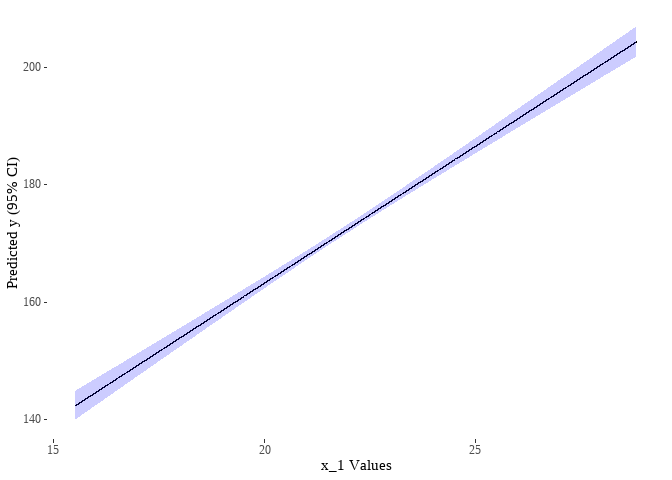

```r
ggplot(data = sim.result, aes(x = x_1_range)) +
  xlab("x_1 Values") +
  ylab("Predicted y (95% CI)") +
  geom_line(aes(y = ev)) +
  geom_ribbon(aes(ymin = lci, ymax = uci),
    fill = "blue", alpha = 0.2) +
  theme_tufte()
```

*Notes*

1. We now have slimmer confidence intervals in the center of the conditional distributions, because this is where the most information is - so we are more certain!!
2. We have now incorporated the distribution of our $\beta$s into predictions about $y$; we can not only say something about $y$, but about how certain we are under different *SUBSTANTIVE* assumptions in our data.

## Include Session, System, Package Information

```r
library(sessioninfo)
library(pander)
edregs_ms1.Rmd_session_2020_04_28 <- sessionInfo()
pander::pander(edregs_ms1.Rmd_session_2020_04_28)
```

**R version 4.0.3 (2020-10-10)**

**Platform:** x86_64-w64-mingw32/x64 (64-bit)

**locale:** *LC_COLLATE=English_United States.1252*, *LC_CTYPE=English_United States.1252*, *LC_MONETARY=English_United States.1252*, *LC_NUMERIC=C* and *LC_TIME=English_United States.1252*

**attached base packages:** *stats*, *graphics*, *grDevices*, *utils*, *datasets*, *methods* and *base*

**other attached packages:** *pander(v.0.6.3)*, *sessioninfo(v.1.1.1)*, *kableExtra(v.1.3.1)*, *showtext(v.0.9)*, *showtextdb(v.3.0)*, *sysfonts(v.0.8.1)*, *ggExtra(v.0.9)*, *RColorBrewer(v.1.1-2)*, *MASS(v.7.3-53)*, *broom(v.0.7.2)*, *forcats(v.0.5.0)*, *stringr(v.1.4.0)*, *dplyr(v.1.0.2)*, *purrr(v.0.3.4)*, *readr(v.1.4.0)*, *tidyr(v.1.1.2)*, *tibble(v.3.0.4)*, *tidyverse(v.1.3.0)*, *ggthemes(v.4.2.0)* and *ggplot2(v.3.3.2)*

**loaded via a namespace (and not attached):** *httr(v.1.4.2)*, *jsonlite(v.1.7.1)*, *viridisLite(v.0.3.0)*, *modelr(v.0.1.8)*, *shiny(v.1.5.0)*, *assertthat(v.0.2.1)*, *highr(v.0.8)*, *blob(v.1.2.1)*, *cellranger(v.1.1.0)*, *yaml(v.2.2.1)*, *pillar(v.1.4.6)*, *backports(v.1.1.10)*, *glue(v.1.4.2)*, *digest(v.0.6.27)*, *promises(v.1.1.1)*, *rvest(v.0.3.6)*, *colorspace(v.1.4-1)*, *htmltools(v.0.5.0)*, *httpuv(v.1.5.4)*, *pkgconfig(v.2.0.3)*, *haven(v.2.3.1)*, *xtable(v.1.8-4)*, *scales(v.1.1.1)*, *webshot(v.0.5.2)*, *later(v.1.1.0.1)*, *farver(v.2.0.3)*, *generics(v.0.0.2)*, *ellipsis(v.0.3.1)*, *withr(v.2.3.0)*, *cli(v.2.1.0)*, *magrittr(v.1.5)*, *crayon(v.1.3.4)*, *readxl(v.1.3.1)*, *mime(v.0.9)*, *evaluate(v.0.14)*, *ps(v.1.4.0)*, *fs(v.1.5.0)*, *fansi(v.0.4.1)*, *xml2(v.1.3.2)*, *tools(v.4.0.3)*, *hms(v.0.5.3)*, *lifecycle(v.0.2.0)*, *munsell(v.0.5.0)*, *reprex(v.0.3.0)*, *compiler(v.4.0.3)*, *rlang(v.0.4.8)*, *grid(v.4.0.3)*, *rstudioapi(v.0.11)*, *miniUI(v.0.1.1.1)*, *labeling(v.0.4.2)*, *rmarkdown(v.2.5.2)*, *gtable(v.0.3.0)*, *DBI(v.1.1.0)*, *curl(v.4.3)*, *R6(v.2.5.0)*, *lubridate(v.1.7.9)*, *knitr(v.1.30)*, *fastmap(v.1.0.1)*, *stringi(v.1.5.3)*, *Rcpp(v.1.0.5)*, *vctrs(v.0.3.4)*, *dbplyr(v.1.4.4)*, *tidyselect(v.1.1.0)* and *xfun(v.0.18)*

## Export Session Information to Text File

```r
sink("../results/replication_data/session_info.txt", append = FALSE)
print(sessioninfo::session_info(include_base = TRUE))
sink()
```